# How I Made Decisions Around Price Changes

## Stepping into the cold U.S stock market…

Over several weeks, I tracked asset prices and my instincts whether I felt like buying, selling, or doing nothing. Here’s what I discovered.

## Price range by weekdays & my instinct

I wanted to understand how prices changed across the week, and whether my instincts aligned with those price patterns.

- Weekends were treated as Fridays.
- Box + jitter shows distribution of prices per weekday.
- Shows my instincts (Buy / Leave / Sell).

It looks like prices tend to be higher on Fridays, which is also when I often feel like selling.

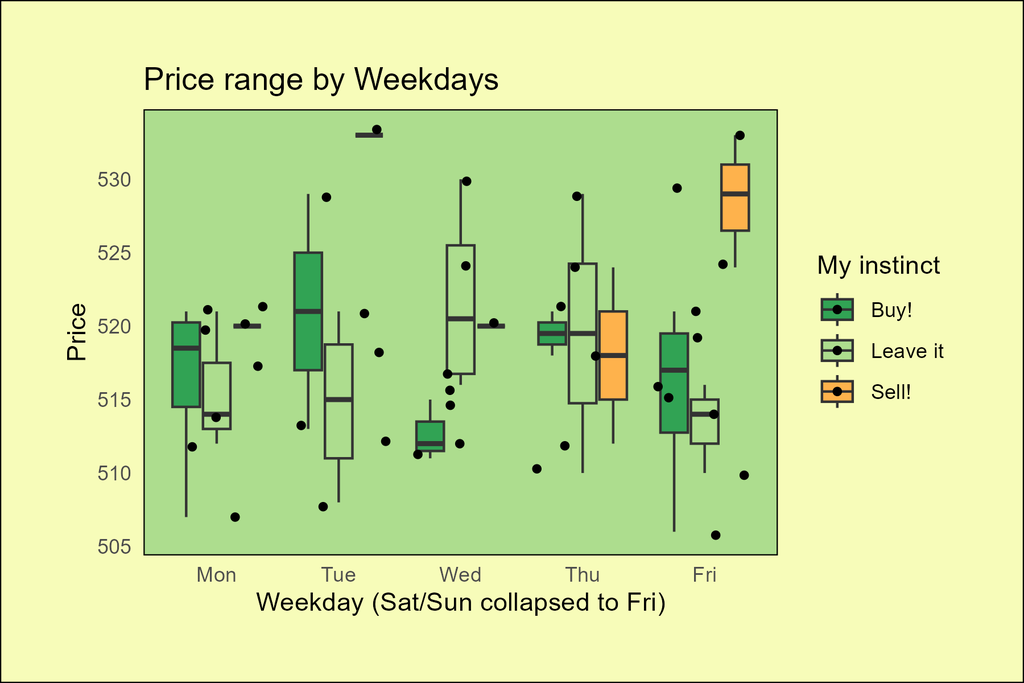

## How many actions did I take?

Next, I looked at how often I thought about buying/selling/leaving across different weeks, and whether those decisions turned out to be good.

- The bars show my weekly actions, broken down by instinct.
- Split by result (good or bad).
- Shows my instincts (Buy / Leave / Sell).

So far, not too bad! Most of my decisions turned out well.

For now, at least…

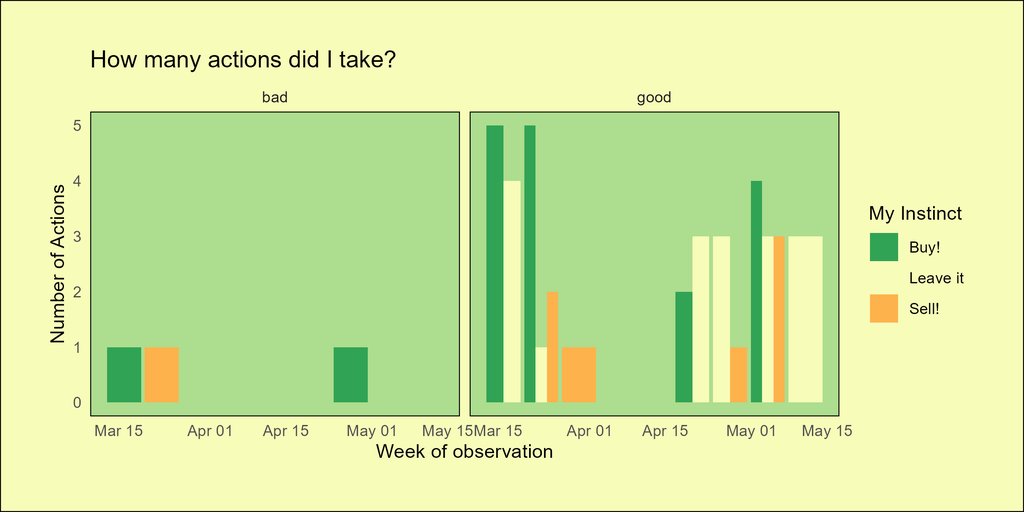

## Price distribution — action vs inaction

I also wanted to know: was taking action better than doing nothing?

- This plot compares the price when I did take action vs. when I didn’t.
- It’s also colored by whether the result was good or bad.

Interestingly, doing nothing often led to better outcomes. That might be because inaction helps avoid losses in uncertain conditions which makes sense for someone like me who tends to trade actively.

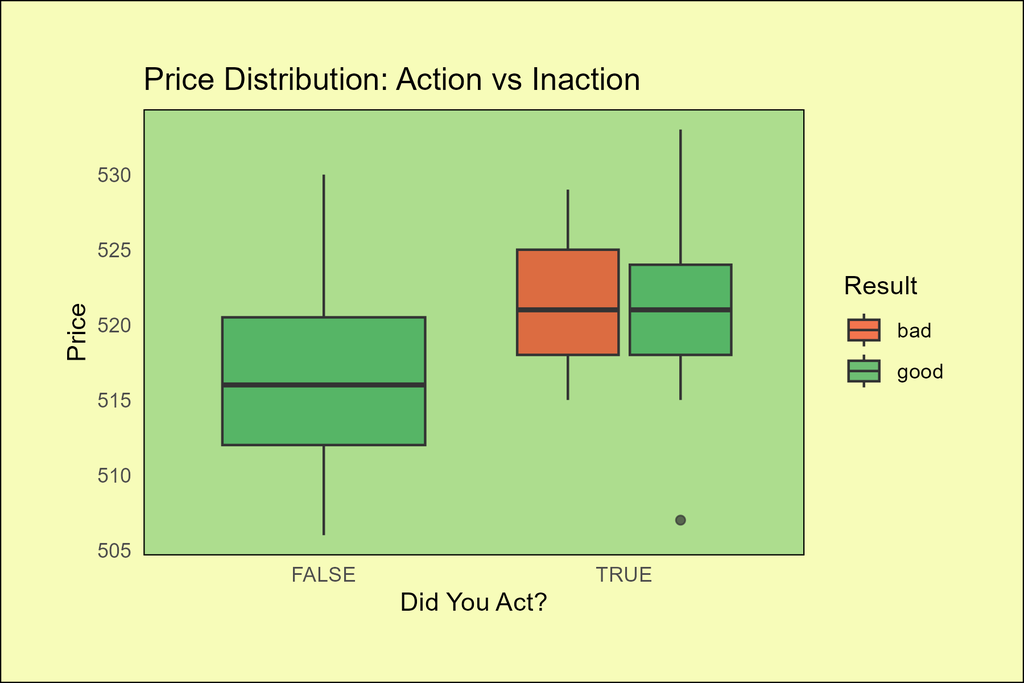

## Trend and moments of action

Finally, I looked at the smoothed price trend, and overlaid when I acted and when those decisions were bad.

In one case, I thought the price would drop, but instead, it climbed, making that my worst decision. Still, even that trade turned out profitable. Not bad!

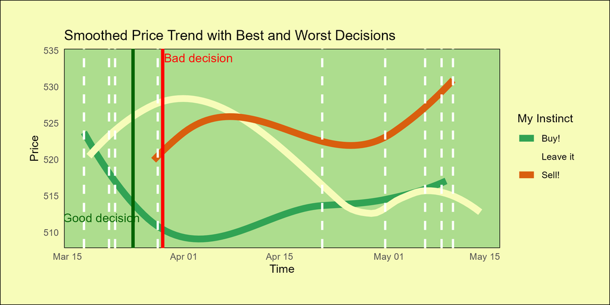

## Conclusion

[figure not shown]